# Integration of single-nucleus and spatial transcriptomics reveals the molecular landscape of the human hippocampus

## Overview

Welcome to the `spatial_HPC` project! In this study, we generated spatially-resolved transcriptomics (SRT) and single-nucleus RNA-sequencing (snRNA-seq) data from adjacent tissue sections of the anterior human hippocampus across ten adult neurotypical donors. SRT data was generated using [10x Genomics **Visium**](https://www.10xgenomics.com/products/spatial-gene-expression) (n=36 capture areas) and [10x Genomics **Visium Spatial Proteogenomics** (SPG)](https://www.10xgenomics.com/products/spatial-proteogenomics) (n=8 capture areas). snRNA-seq data was generated using [10x Genomics **Chromium**](https://www.10xgenomics.com/products/single-cell-gene-expression) (n=26 total snRNA-seq libraries).

If you tweet about this website, the data or the R package please use the `#spatial_HPC` hashtag. You can find previous tweets that way as shown [here](https://twitter.com/search?q=%23spatialDLPFC&src=typed_query).

Thank you for your interest in our work!

## Study design

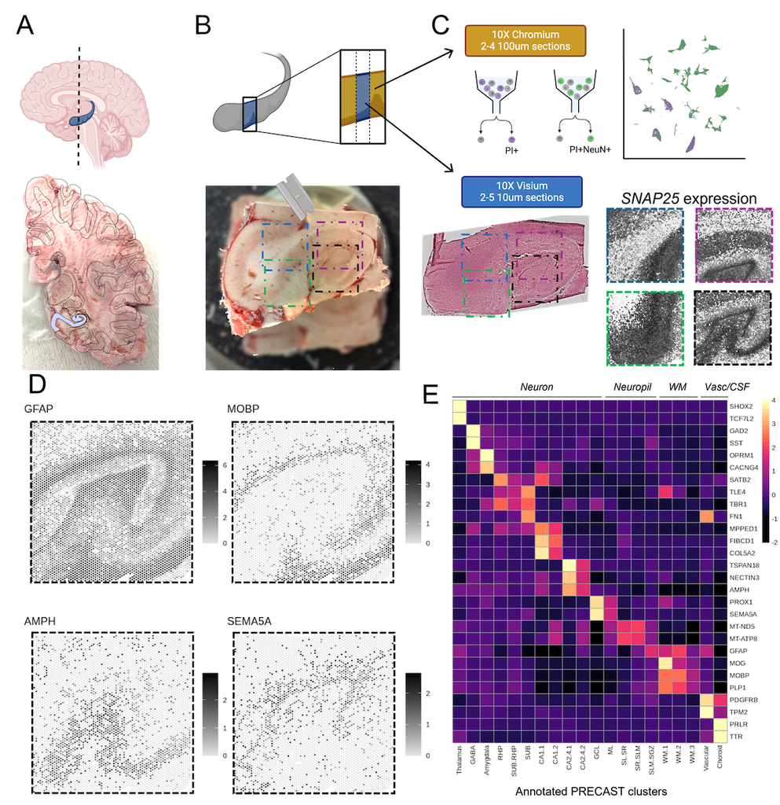

## Interactive Websites

All of these interactive websites are powered by open source software, namely:

- 🔍 [`samui`](http://dx.doi.org/10.1017/S2633903X2300017X)
- 👀 [`iSEE`](https://doi.org/10.12688%2Ff1000research.14966.1)

We provide the following interactive websites, organized by dataset with software labeled by emojis:

- Visium (n = 44)
  - 👀 https://libd.shinyapps.io/pseudobulk_HPC/
    - Provides tools for visualization of pseudobulked Visium data.
  - 🔍 [HPC Samui browser](https://samuibrowser.com/from?url=data.libd.org/samuibrowser/&s=Br3942&s=Br8325&s=Br2720&s=Br2743&s=Br3942-VSPG&s=Br6423&s=Br6432&s=Br6471&s=Br6522&s=Br8325-VSPG&s=Br8492&s=Br8667)
    - Provides interactive spot-level visualization of Visium data.
- snRNA-seq (n = 26)
  - 👀 https://libd.shinyapps.io/HPC_snRNAseq_data/
    - Provides tools for visualization of snRNA-seq data.

## Data Access

All data, including raw FASTQ files and `SpaceRanger`/`CellRanger` processed data outputs, can be accessed via Gene Expression Omnibus (GEO) under accessions GSE264692 (SRT) and GSE264624 (snRNA-seq). Data can also be accessed from the NIMH Data Archive (NDA) under study ID 2637.

## Cite our Work

Thompson, J.R., Nelson, E.D., Tippani, M. et al. An integrated single-nucleus and spatial transcriptomics atlas reveals the molecular landscape of the human hippocampus. Nat Neurosci 28, 1990–2004 (2025). https://doi.org/10.1038/s41593-025-02022-0

## Contact

We value public questions, as they allow other users to learn from the answers. If you have any questions, please ask them at LieberInstitute/spatial_hpc/issues and refrain from emailing us. Thank you again for your interest in our work!

## Internal

- JHPCE location: `/dcs04/lieber/lcolladotor/spatialHPC_LIBD4035/spatial_hpc`

### Files:

- `code`: Scripts for running all analyses.
- `plots`: plots generated by analysis scripts.
- `processed-data`
  - `Images`: images used for running `SpaceRanger` and `VistoSeg`.
  - `spaceranger`: `SpaceRanger` output files.
- `raw-data`
  - `sample_info`: metadata about samples.
- `snRNAseq_HPC`: code, plots, and data for snRNA-seq analyses.
- Code for running [`GraphST`](https://doi.org/10.1038/s41467-023-36796-3) clustering pipeline can be found here: https://github.com/JianingYao/SpatialHPC_graphST_multipleSample

This GitHub repository is organized along the [*R/Bioconductor-powered Team Data Science* group guidelines](https://lcolladotor.github.io/bioc_team_ds/organizing-your-work.html#.Yaf9fPHMIdk). It follows the LieberInstitute/template_project structure.